# Fulfillment center order managementII

Taewon Kim

2021 12 5

## Background and purpose of the project

Outbound capacity plan is important to allocate total orders and currently it seems that outbound volume is getting increased. We need to identify the trend with order data. Along with the trend, adjusted capacity needs to be applied reflecting the current trend.

```r
year <- 2021
month <- 10
day <- 1:31
Date <- as.Date(ISOdate(year, month, day))
Date
```

```
##  [1] "2021-10-01" "2021-10-02" "2021-10-03" "2021-10-04" "2021-10-05"
##  [6] "2021-10-06" "2021-10-07" "2021-10-08" "2021-10-09" "2021-10-10"
## [11] "2021-10-11" "2021-10-12" "2021-10-13" "2021-10-14" "2021-10-15"
## [16] "2021-10-16" "2021-10-17" "2021-10-18" "2021-10-19" "2021-10-20"
## [21] "2021-10-21" "2021-10-22" "2021-10-23" "2021-10-24" "2021-10-25"
## [26] "2021-10-26" "2021-10-27" "2021-10-28" "2021-10-29" "2021-10-30"
## [31] "2021-10-31"
```

```r
FC1 <- data.frame(c(1:31),Date, rep("FC1", 31), rnorm(31,0.01*30000,1000), rnorm(31,0.03*30000,1000),rnorm(31,0.01*30000),rnorm(31,0.05*30000),rnorm(31,0.04*30000),rnorm(31,0.05*30000),rnorm(31,0.04*30000),rnorm(31,0.05*30000),rnorm(31,0.05*30000),rnorm(31,0.05*30000),rnorm(31,0.05*30000),rnorm(31,0.05*30000),rnorm(31,0.05*30000),rnorm(31,0.06*30000),rnorm(31,0.08*30000),rnorm(31,0.07*30000),rnorm(31,0.07*30000),rnorm(31,0.07*30000),rnorm(31,0.05*30000),rnorm(31,0.02*30000),rnorm(31,0.01*30000),rnorm(31,0.01*30000,500),rnorm(31,0.01*30000,500),rnorm(31,0*30000,0) )
names(FC1) <- c("Seq", "Date","FC_Name", "06","07","08","09","10","11","12","13","14","15","16","17","18","19","20","21","22","23","24","01","02","03","04","05")
FC1
```

```
##    Seq       Date FC_Name           06          07       08       09       10
## 1    1 2021-10-01     FC1  -554.472113  -153.19982 299.3623 1500.286 1198.970
## 2    2 2021-10-02     FC1  -849.144871  -596.03644 299.2256 1501.077 1201.090
## 3    3 2021-10-03     FC1     8.880076   735.69119 300.6480 1499.599 1198.788
## 4    4 2021-10-04     FC1  -242.567670  -690.86702 299.7290 1499.469 1200.592
## 5    5 2021-10-05     FC1  1723.734850   672.26942 300.8263 1500.707 1199.696
## 6    6 2021-10-06     FC1   591.159924  2318.53990 299.4704 1499.320 1199.488
## 7    7 2021-10-07     FC1  -157.851841  2023.64006 300.1664 1498.663 1200.012
## 8    8 2021-10-08     FC1  -364.642437  1726.85094 299.6630 1500.685 1199.739
## 9    9 2021-10-09     FC1   835.117187  1563.20958 298.3133 1499.709 1201.723
## 10  10 2021-10-10     FC1  1912.608376 -1040.24019 299.4359 1500.537 1199.958
## 11  11 2021-10-11     FC1  1641.745921  1635.43605 300.3310 1500.199 1199.419
## 12  12 2021-10-12     FC1   275.218248   154.84092 299.4729 1499.493 1199.229
## 13  13 2021-10-13     FC1 -1323.441331  1544.33789 300.5795 1500.064 1199.916
## 14  14 2021-10-14     FC1  -833.953747  -721.90036 300.4948 1498.933 1200.221
```

[output cut: 113 more lines]

```r
FC2 <- data.frame(c(1:31), Date, rep("FC2", 31), rnorm(31,0.01*20000,1000), rnorm(31,0.03*20000,1000),rnorm(31,0.01*20000),rnorm(31,0.05*20000),rnorm(31,0.04*20000),rnorm(31,0.05*20000),rnorm(31,0.04*20000),rnorm(31,0.05*20000),rnorm(31,0.05*20000),rnorm(31,0.05*20000),rnorm(31,0.05*20000),rnorm(31,0.05*20000),rnorm(31,0.05*20000),rnorm(31,0.06*20000),rnorm(31,0.08*20000),rnorm(31,0.07*20000),rnorm(31,0.07*20000),rnorm(31,0.07*20000),rnorm(31,0.05*20000),rnorm(31,0.02*20000),rnorm(31,0.01*20000),rnorm(31,0.01*20000,500),rnorm(31,0.01*20000,500),rnorm(31,0*20000,0) )
names(FC2) <- c("Seq","Date","FC_Name", "06","07","08","09","10","11","12","13","14","15","16","17","18","19","20","21","22","23","24","01","02","03","04","05")
FC2
```

```
##    Seq       Date FC_Name           06          07       08        09       10
## 1    1 2021-10-01     FC2  -158.906700  883.141336 200.4249 1000.1459 800.6994
## 2    2 2021-10-02     FC2   -91.957507 1962.347539 201.6157  999.2828 798.9502
## 3    3 2021-10-03     FC2 -1690.098234  -10.589278 200.8464 1001.0016 799.5194
## 4    4 2021-10-04     FC2  -510.084035 -155.826261 201.3160  999.4564 800.3775
## 5    5 2021-10-05     FC2  1502.929098 1529.725818 199.7107 1000.6475 800.2745
## 6    6 2021-10-06     FC2  1932.116880 -383.146831 199.2075  999.7857 800.2107
## 7    7 2021-10-07     FC2  -687.548659  872.784140 201.1120  998.7561 799.9235
## 8    8 2021-10-08     FC2    52.869710   34.342128 199.5059  999.0643 799.1370
## 9    9 2021-10-09     FC2   132.783049 3224.983001 200.5017 1000.5751 800.6212
## 10  10 2021-10-10     FC2  -459.731793 -885.329645 199.6407 1000.2234 800.0781
## 11  11 2021-10-11     FC2  -684.946153   -5.779595 201.5971  998.3404 799.2280
## 12  12 2021-10-12     FC2   147.891447  305.979302 200.0965  999.9851 800.7797
## 13  13 2021-10-13     FC2   457.873432  204.029763 198.6605  997.6311 799.8496
## 14  14 2021-10-14     FC2  2381.203895 -511.766796 197.5474  999.0907 799.9941
```

[output cut: 113 more lines]

```r
FC3 <- data.frame(c(1:31), Date, rep("FC3", 31), rnorm(31,0.01*10000,1000), rnorm(31,0.03*10000,1000),rnorm(31,0.01*10000),rnorm(31,0.05*10000),rnorm(31,0.04*10000),rnorm(31,0.05*10000),rnorm(31,0.04*10000),rnorm(31,0.05*10000),rnorm(31,0.05*10000),rnorm(31,0.05*10000),rnorm(31,0.05*10000),rnorm(31,0.05*10000),rnorm(31,0.05*10000),rnorm(31,0.06*10000),rnorm(31,0.08*10000),rnorm(31,0.07*10000),rnorm(31,0.07*10000),rnorm(31,0.07*10000),rnorm(31,0.05*10000),rnorm(31,0.02*10000),rnorm(31,0.01*10000),rnorm(31,0.01*10000,500),rnorm(31,0.01*10000,500),rnorm(31,0*10000,0) )
names(FC3) <- c("Seq","Date","FC_Name", "06","07","08","09","10","11","12","13","14","15","16","17","18","19","20","21","22","23","24","01","02","03","04","05")
FC3
```

```
##    Seq       Date FC_Name            06          07        08       09       10
## 1    1 2021-10-01     FC3  1330.9833733   444.30963  99.85414 497.6425 400.7513
## 2    2 2021-10-02     FC3  2142.9989751   962.51213  98.76152 499.9459 399.8367
## 3    3 2021-10-03     FC3  -537.9182900  2733.18891  99.86694 501.2481 402.1422
## 4    4 2021-10-04     FC3  -330.0150648    39.90643 101.49501 499.8725 400.8186
## 5    5 2021-10-05     FC3    52.6019164 -1857.01704 100.78094 500.0201 399.4730
## 6    6 2021-10-06     FC3  1332.7114148   358.50921 101.17156 500.3668 400.6923
## 7    7 2021-10-07     FC3  -993.0200372 -1073.32336 100.07020 499.5436 399.3381
## 8    8 2021-10-08     FC3  1693.1861430  2437.87108 100.96266 499.2061 402.1486
## 9    9 2021-10-09     FC3  -811.3449550  1777.77237 100.09634 499.9697 398.7846
## 10  10 2021-10-10     FC3  -201.9742396  1143.86654  99.09611 500.9637 401.2420
## 11  11 2021-10-11     FC3   325.5012558 -1825.76704  98.90633 498.8928 400.2823
## 12  12 2021-10-12     FC3  -794.3150549   -97.36023 101.33307 498.8234 401.7843
## 13  13 2021-10-13     FC3 -1995.4523091  1128.88351  98.69527 501.6391 399.1997
## 14  14 2021-10-14     FC3 -1097.3239975  -262.57109 100.35432 500.5369 400.3801
```

[output cut: 113 more lines]

```r
FC1$Capacity <- 30000
FC2$Capacity <- 20000
FC3$Capacity <- 10000

FC1$Daily_order <- rowSums(FC1[,c(4:27)],na.rm=TRUE)
FC2$Daily_order <- rowSums(FC2[,c(4:27)],na.rm=TRUE)
FC3$Daily_order <- rowSums(FC3[,c(4:27)],na.rm=TRUE)


All_FC_Data <- rbind(FC1, FC2, FC3)

All_FC_Data
```

```
##    Seq       Date FC_Name            06           07        08        09
## 1    1 2021-10-01     FC1  -554.4721130  -153.199820 299.36225 1500.2855
## 2    2 2021-10-02     FC1  -849.1448708  -596.036439 299.22560 1501.0768
## 3    3 2021-10-03     FC1     8.8800764   735.691190 300.64799 1499.5995
## 4    4 2021-10-04     FC1  -242.5676695  -690.867022 299.72897 1499.4693
## 5    5 2021-10-05     FC1  1723.7348498   672.269415 300.82634 1500.7065
## 6    6 2021-10-06     FC1   591.1599243  2318.539901 299.47041 1499.3205
## 7    7 2021-10-07     FC1  -157.8518413  2023.640061 300.16644 1498.6634
## 8    8 2021-10-08     FC1  -364.6424366  1726.850945 299.66302 1500.6845
## 9    9 2021-10-09     FC1   835.1171867  1563.209584 298.31328 1499.7085
## 10  10 2021-10-10     FC1  1912.6083763 -1040.240195 299.43588 1500.5374
## 11  11 2021-10-11     FC1  1641.7459208  1635.436049 300.33096 1500.1985
## 12  12 2021-10-12     FC1   275.2182482   154.840915 299.47288 1499.4930
## 13  13 2021-10-13     FC1 -1323.4413306  1544.337888 300.57947 1500.0643
## 14  14 2021-10-14     FC1  -833.9537468  -721.900363 300.49477 1498.9334
```

[output cut: 455 more lines]

## Data description and Forecasting

Mean and Standard deviation are shown for each FC and regression model is used for forecast.

```
##       FC1       FC2       FC3
## 29477.630 19644.026  9678.077
```

```
##      FC1      FC2      FC3
## 1544.628 1620.202 2026.913
```

```
##    Seq       Date FC_Name            06           07        08        09
## 1    1 2021-10-01     FC1  -554.4721130  -153.199820 299.36225 1500.2855
## 2    2 2021-10-02     FC1  -849.1448708  -596.036439 299.22560 1501.0768
## 3    3 2021-10-03     FC1     8.8800764   735.691190 300.64799 1499.5995
## 4    4 2021-10-04     FC1  -242.5676695  -690.867022 299.72897 1499.4693
## 5    5 2021-10-05     FC1  1723.7348498   672.269415 300.82634 1500.7065
## 6    6 2021-10-06     FC1   591.1599243  2318.539901 299.47041 1499.3205
## 7    7 2021-10-07     FC1  -157.8518413  2023.640061 300.16644 1498.6634
## 8    8 2021-10-08     FC1  -364.6424366  1726.850945 299.66302 1500.6845
## 9    9 2021-10-09     FC1   835.1171867  1563.209584 298.31328 1499.7085
## 10  10 2021-10-10     FC1  1912.6083763 -1040.240195 299.43588 1500.5374
## 11  11 2021-10-11     FC1  1641.7459208  1635.436049 300.33096 1500.1985
## 12  12 2021-10-12     FC1   275.2182482   154.840915 299.47288 1499.4930
## 13  13 2021-10-13     FC1 -1323.4413306  1544.337888 300.57947 1500.0643
## 14  14 2021-10-14     FC1  -833.9537468  -721.900363 300.49477 1498.9334
```

[output cut: 455 more lines]

```
## FC1 FC2 FC3
##  11  11  15
```

```
##    Point Forecast    Lo 80    Hi 80 Lo 95    Hi 95
## 32       29476.33 27462.86 31489.79 26397 32555.65
## 33       29476.33 27462.86 31489.79 26397 32555.65
## 34       29476.33 27462.86 31489.79 26397 32555.65
## 35       29476.33 27462.86 31489.79 26397 32555.65
## 36       29476.33 27462.86 31489.79 26397 32555.65
## 37       29476.33 27462.86 31489.79 26397 32555.65
## 38       29476.33 27462.86 31489.79 26397 32555.65
## 39       29476.33 27462.86 31489.79 26397 32555.65
## 40       29476.33 27462.86 31489.79 26397 32555.65
## 41       29476.33 27462.86 31489.79 26397 32555.65
## 42       29476.33 27462.86 31489.79 26397 32555.65
## 43       29476.33 27462.86 31489.79 26397 32555.65
## 44       29476.33 27462.86 31489.79 26397 32555.65
## 45       29476.33 27462.86 31489.79 26397 32555.65
```

[output cut: 16 more lines]

```
##    Point Forecast    Lo 80    Hi 80    Lo 95   Hi 95
## 32       19644.61 17532.64 21756.58 16414.63 22874.6
## 33       19644.61 17532.64 21756.58 16414.63 22874.6
## 34       19644.61 17532.64 21756.58 16414.63 22874.6
## 35       19644.61 17532.64 21756.58 16414.63 22874.6
## 36       19644.61 17532.64 21756.58 16414.63 22874.6
## 37       19644.61 17532.64 21756.58 16414.63 22874.6
## 38       19644.61 17532.64 21756.58 16414.63 22874.6
## 39       19644.61 17532.64 21756.58 16414.63 22874.6
## 40       19644.61 17532.64 21756.58 16414.63 22874.6
## 41       19644.61 17532.64 21756.58 16414.63 22874.6
## 42       19644.61 17532.64 21756.58 16414.63 22874.6
## 43       19644.61 17532.64 21756.58 16414.63 22874.6
## 44       19644.61 17532.64 21756.58 16414.62 22874.6
## 45       19644.61 17532.64 21756.58 16414.62 22874.6
```

[output cut: 16 more lines]

```
##    Point Forecast    Lo 80    Hi 80    Lo 95    Hi 95
## 32       9678.355 7036.222 12320.49 5637.562 13719.15
## 33       9678.355 7036.222 12320.49 5637.562 13719.15
## 34       9678.355 7036.222 12320.49 5637.562 13719.15
## 35       9678.355 7036.222 12320.49 5637.562 13719.15
## 36       9678.355 7036.222 12320.49 5637.562 13719.15
## 37       9678.355 7036.222 12320.49 5637.562 13719.15
## 38       9678.355 7036.222 12320.49 5637.562 13719.15
## 39       9678.355 7036.222 12320.49 5637.562 13719.15
## 40       9678.355 7036.222 12320.49 5637.562 13719.15
## 41       9678.355 7036.222 12320.49 5637.562 13719.15
## 42       9678.355 7036.222 12320.49 5637.562 13719.15
## 43       9678.355 7036.222 12320.49 5637.562 13719.15
## 44       9678.355 7036.222 12320.49 5637.561 13719.15
## 45       9678.355 7036.222 12320.49 5637.561 13719.15
```

[output cut: 16 more lines]

```
##
## Call:
## lm(formula = FC1$Daily_order ~ FC1$Seq)
##
## Coefficients:
## (Intercept)      FC1$Seq
##    28729.51        46.76
```

```
##
## Call:
## lm(formula = FC1$Daily_order ~ FC1$Seq)
##
## Residuals:
##     Min      1Q  Median      3Q     Max
## -2620.0  -945.6  -212.9  1048.7  3001.5
##
## Coefficients:
##             Estimate Std. Error t value Pr(>|t|)
## (Intercept) 28729.51     555.93  51.678   <2e-16 ***
## FC1$Seq        46.76      30.33   1.542    0.134
## ---
## Signif. codes:  0 '***' 0.001 '**' 0.01 '*' 0.05 '.' 0.1 ' ' 1
##
## Residual standard error: 1510 on 29 degrees of freedom
## Multiple R-squared:  0.07575,    Adjusted R-squared:  0.04388
## F-statistic: 2.377 on 1 and 29 DF,  p-value: 0.134
```

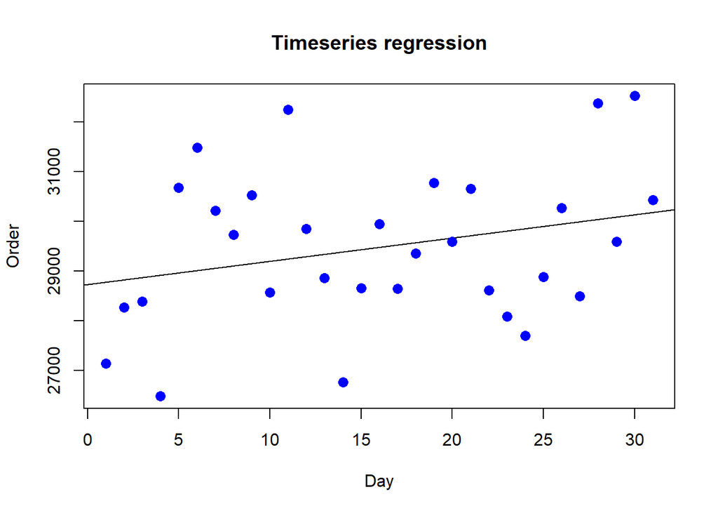

```
##
## Call:
## lm(formula = FC2$Daily_order ~ FC2$Seq)
##
## Coefficients:
## (Intercept)      FC2$Seq
##   19526.025        7.375
```

```
##
## Call:
## lm(formula = FC2$Daily_order ~ FC2$Seq)
##
## Residuals:
##     Min      1Q  Median      3Q     Max
## -4835.3  -754.1  -113.8  1160.9  3512.7
##
## Coefficients:
##              Estimate Std. Error t value Pr(>|t|)
## (Intercept) 19526.025    606.042  32.219   <2e-16 ***
## FC2$Seq         7.375     33.062   0.223    0.825
## ---
## Signif. codes:  0 '***' 0.001 '**' 0.01 '*' 0.05 '.' 0.1 ' ' 1
##
## Residual standard error: 1646 on 29 degrees of freedom
## Multiple R-squared:  0.001713,   Adjusted R-squared:  -0.03271
## F-statistic: 0.04976 on 1 and 29 DF,  p-value: 0.825
```

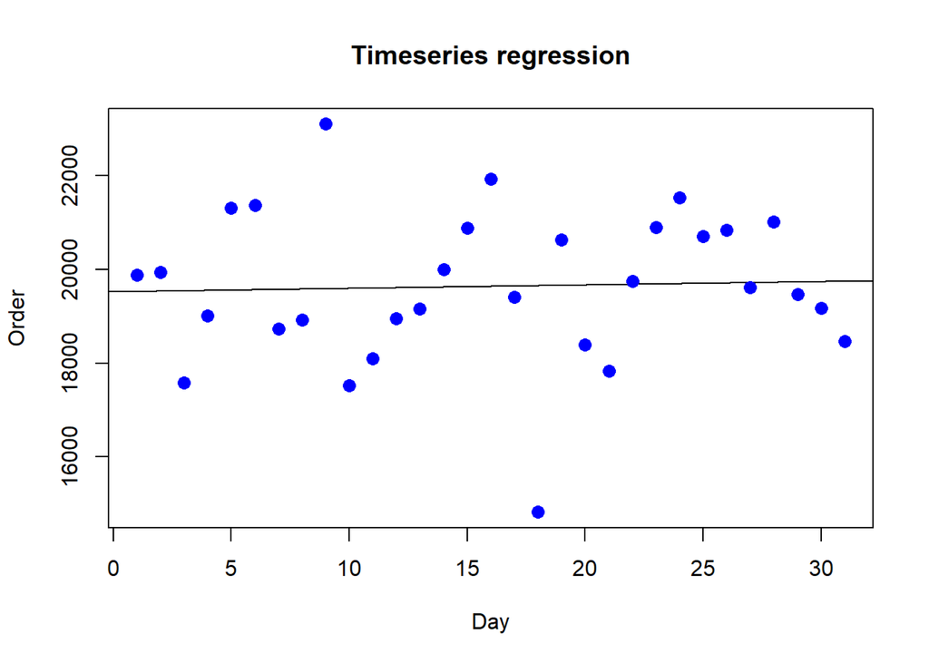

```
##
## Call:
## lm(formula = FC3$Daily_order ~ FC1$Seq)
##
## Coefficients:
## (Intercept)      FC1$Seq
##    10062.55       -24.03
```

```
##
## Call:
## lm(formula = FC3$Daily_order ~ FC1$Seq)
##
## Residuals:
##     Min      1Q  Median      3Q     Max
## -2982.6 -1770.8   382.6  1576.3  4770.6
##
## Coefficients:
##             Estimate Std. Error t value Pr(>|t|)
## (Intercept) 10062.55     754.40  13.338 6.66e-14 ***
## FC1$Seq       -24.03      41.16  -0.584    0.564
## ---
## Signif. codes:  0 '***' 0.001 '**' 0.01 '*' 0.05 '.' 0.1 ' ' 1
##
## Residual standard error: 2050 on 29 degrees of freedom
## Multiple R-squared:  0.01162,    Adjusted R-squared:  -0.02246
## F-statistic: 0.3409 on 1 and 29 DF,  p-value: 0.5638
```

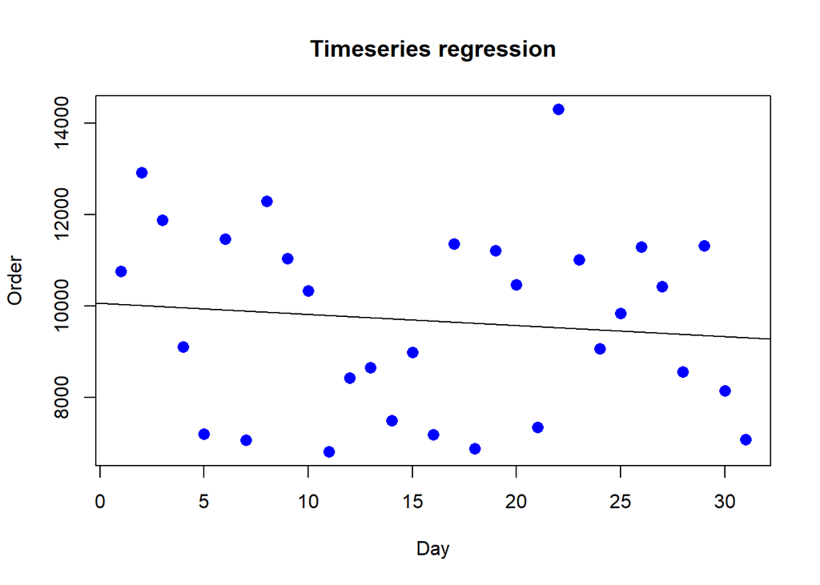

## Conclusion

In order to use Lear regression model for this case, Adjusted R sqare and P-value should be within the proper range. In this case, Every Adjusted R sqares for thress FCs are less than 0.1 which is very low which indicate the inferred model is not explainable for the real situation. Besides, P-value is much more than 0.05 which also makes the model not trustworthy. Due to the high fluctuation in daily order in each fulfillment center, capacity management is very difficult. In order to reduce the order fluctuation in each fulfillment center, combining fulfillment centers into 1 or 2 seems required.